# Проект Обучение с учителем качество модели - git

```python
!pip install phik -q
```

```python
!pip install shap -q
```

```python
import pandas as pd
import numpy as np
import shap
from termcolor import colored # цвет
from matplotlib import pyplot as plt # графики
import seaborn as sns # графики
from scipy.stats import pearsonr
import phik # расчет коэффициентов корреляции
import copy

# загружаем классы для подготовки данных
from sklearn.preprocessing import (
    OneHotEncoder
    ,OrdinalEncoder
    ,StandardScaler
    ,MinMaxScaler
    ,RobustScaler
)

from sklearn.compose import ColumnTransformer
from sklearn.preprocessing import LabelEncoder
from sklearn.cluster import KMeans # метод кластеризации
from sklearn.impute import SimpleImputer # загружаем класс для работы с пропусками
from sklearn.model_selection import RandomizedSearchCV, train_test_split # импортируем класс RandomizedSearchCV

# загружаем нужные модели
from sklearn.linear_model import LogisticRegression
from sklearn.neighbors import KNeighborsClassifier
from sklearn.tree import DecisionTreeClassifier
from sklearn.svm import SVC

# загружаем класс pipeline
from sklearn.pipeline import Pipeline

# анализ эффективности модели
from sklearn.metrics import (
 roc_auc_score # загружаем функцию для работы с метриками
 ,mean_absolute_error # расчет ошибки
 ,r2_score # расчет ошибки
 ,mean_squared_error # импорт MSE для RMSE аргумент функции squared = False
 ,confusion_matrix # матрица ошибок (первый/второй год)
 ,accuracy_score # проверка ошибки логистической регрессии
 ,recall_score # ошибки второго рода
 ,precision_score # Ошибки первого рода
)
```

## Загрузка данных

```python
market_file = pd.read_csv('/datasets/market_file.csv')
market_money = pd.read_csv('/datasets/market_money.csv')
market_time = pd.read_csv('/datasets/market_time.csv')
money = pd.read_csv('/datasets/money.csv', sep = ';', decimal = ',')
```

```python
# Изменение толщины текста
def big_bold_text(text):
    return colored(text, attrs=['bold'])
```

```python
#Создадим словарь соответствия фрейма и его имени
dictionary_with_frames ={
    'market_file': market_file,
    'market_money': market_money,
    'market_time': market_time,
    'money': money
}
```

## Предобработка данных

### Проверка на наличие дубликатов, пропусков. Вывод формата данных в столбцах, структуры таблицы и наименование столбцов

**Преобразуем наименование столбцов**

```python
for row in dictionary_with_frames:
    dictionary_with_frames[row].columns = dictionary_with_frames[row].columns.str.lower()
    dictionary_with_frames[row].columns = dictionary_with_frames[row].columns.str.replace(' ', '_', regex=True)
```

```python
#Функция тестировани данных
def test_df (dictionary_with_frames_col):
    for row in dictionary_with_frames_col:
        print(big_bold_text('Таблица: '),row)
        print(big_bold_text('Количество дубликатов: '),dictionary_with_frames[row].duplicated().sum())
        if dictionary_with_frames[row].duplicated().sum()>0:
            print('')
            print(big_bold_text('Строки с дубликатами:'))
            display(dictionary_with_frames[row].loc[dictionary_with_frames[row].duplicated()==True])
        print('')
        print(big_bold_text('Информация по таблице\n'))
        dictionary_with_frames[row].info()
        print('')
        print(big_bold_text('Количество пропусков:\n'))
        print(dictionary_with_frames[row].isna().sum())
        print('')
        print(big_bold_text('Вывод первых 5 строк из таблицы\n'))
        display(dictionary_with_frames[row].head(5))
        print(big_bold_text('_____________________________________________________________________________________________________'))
        print('')
test_df(dictionary_with_frames)
```

```
Таблица:  market_file
Количество дубликатов:  0

Информация по таблице

<class 'pandas.core.frame.DataFrame'>
RangeIndex: 1300 entries, 0 to 1299
Data columns (total 13 columns):
 #   Column                               Non-Null Count  Dtype
---  ------                               --------------  -----
 0   id                                   1300 non-null   int64
 1   покупательская_активность            1300 non-null   object
 2   тип_сервиса                          1300 non-null   object
 3   разрешить_сообщать                   1300 non-null   object
 4   маркет_актив_6_мес                   1300 non-null   float64
 5   маркет_актив_тек_мес                 1300 non-null   int64
 6   длительность                         1300 non-null   int64
 7   акционные_покупки                    1300 non-null   float64
 8   популярная_категория                 1300 non-null   object
 9   средний_просмотр_категорий_за_визит  1300 non-null   int64
 10  неоплаченные_продукты_штук_квартал   1300 non-null   int64
 11  ошибка_сервиса                       1300 non-null   int64
 12  страниц_за_визит                     1300 non-null   int64
dtypes: float64(2), int64(7), object(4)
memory usage: 132.2+ KB

Количество пропусков:

id                                     0
покупательская_активность              0
тип_сервиса                            0
разрешить_сообщать                     0
маркет_актив_6_мес                     0
маркет_актив_тек_мес                   0
длительность                           0
акционные_покупки                      0
популярная_категория                   0
средний_просмотр_категорий_за_визит    0
неоплаченные_продукты_штук_квартал     0
ошибка_сервиса                         0
страниц_за_визит                       0
dtype: int64

Вывод первых 5 строк из таблицы
```

|  | id | покупательская_активность | тип_сервиса | разрешить_сообщать | маркет_актив_6_мес | маркет_актив_тек_мес | длительность | акционные_покупки | популярная_категория | средний_просмотр_категорий_за_визит | неоплаченные_продукты_штук_квартал | ошибка_сервиса | страниц_за_визит |
| --- | --- | --- | --- | --- | --- | --- | --- | --- | --- | --- | --- | --- | --- |
| 0 | 215348 | Снизилась | премиум | да | 3.4 | 5 | 121 | 0.00 | Товары для детей | 6 | 2 | 1 | 5 |
| 1 | 215349 | Снизилась | премиум | да | 4.4 | 4 | 819 | 0.75 | Товары для детей | 4 | 4 | 2 | 5 |
| 2 | 215350 | Снизилась | стандартт | нет | 4.9 | 3 | 539 | 0.14 | Домашний текстиль | 5 | 2 | 1 | 5 |
| 3 | 215351 | Снизилась | стандартт | да | 3.2 | 5 | 896 | 0.99 | Товары для детей | 5 | 0 | 6 | 4 |
| 4 | 215352 | Снизилась | стандартт | нет | 5.1 | 3 | 1064 | 0.94 | Товары для детей | 3 | 2 | 3 | 2 |

```
_____________________________________________________________________________________________________

Таблица:  market_money
Количество дубликатов:  0

Информация по таблице

<class 'pandas.core.frame.DataFrame'>
RangeIndex: 3900 entries, 0 to 3899
Data columns (total 3 columns):
 #   Column   Non-Null Count  Dtype
---  ------   --------------  -----
 0   id       3900 non-null   int64
 1   период   3900 non-null   object
 2   выручка  3900 non-null   float64
dtypes: float64(1), int64(1), object(1)
memory usage: 91.5+ KB

Количество пропусков:

id         0
период     0
выручка    0
dtype: int64

Вывод первых 5 строк из таблицы
```

|  | id | период | выручка |
| --- | --- | --- | --- |
| 0 | 215348 | препредыдущий_месяц | 0.0 |
| 1 | 215348 | текущий_месяц | 3293.1 |
| 2 | 215348 | предыдущий_месяц | 0.0 |
| 3 | 215349 | препредыдущий_месяц | 4472.0 |
| 4 | 215349 | текущий_месяц | 4971.6 |

```
_____________________________________________________________________________________________________

Таблица:  market_time
Количество дубликатов:  0

Информация по таблице

<class 'pandas.core.frame.DataFrame'>
RangeIndex: 2600 entries, 0 to 2599
Data columns (total 3 columns):
 #   Column  Non-Null Count  Dtype
---  ------  --------------  -----
 0   id      2600 non-null   int64
 1   период  2600 non-null   object
 2   минут   2600 non-null   int64
dtypes: int64(2), object(1)
memory usage: 61.1+ KB

Количество пропусков:

id        0
период    0
минут     0
dtype: int64

Вывод первых 5 строк из таблицы
```

|  | id | период | минут |
| --- | --- | --- | --- |
| 0 | 215348 | текущий_месяц | 14 |
| 1 | 215348 | предыдцщий_месяц | 13 |
| 2 | 215349 | текущий_месяц | 10 |
| 3 | 215349 | предыдцщий_месяц | 12 |
| 4 | 215350 | текущий_месяц | 13 |

```
_____________________________________________________________________________________________________

Таблица:  money
Количество дубликатов:  0

Информация по таблице

<class 'pandas.core.frame.DataFrame'>
RangeIndex: 1300 entries, 0 to 1299
Data columns (total 2 columns):
 #   Column   Non-Null Count  Dtype
---  ------   --------------  -----
 0   id       1300 non-null   int64
 1   прибыль  1300 non-null   float64
dtypes: float64(1), int64(1)
memory usage: 20.4 KB

Количество пропусков:

id         0
прибыль    0
dtype: int64

Вывод первых 5 строк из таблицы
```

|  | id | прибыль |
| --- | --- | --- |
| 0 | 215348 | 0.98 |
| 1 | 215349 | 4.16 |
| 2 | 215350 | 3.13 |
| 3 | 215351 | 4.87 |
| 4 | 215352 | 4.21 |

```
_____________________________________________________________________________________________________
```

**Проведем анализ категориальных данных**

```python
for row in dictionary_with_frames:
    print(big_bold_text('Таблица: '),row)
    for row_1 in dictionary_with_frames[row].select_dtypes(exclude=np.number):
        display(dictionary_with_frames[row][row_1].value_counts())
```

```
Таблица:  market_file
```

```
Прежний уровень    802
Снизилась          498
Name: покупательская_активность, dtype: int64
```

```
стандарт     914
премиум      376
стандартт     10
Name: тип_сервиса, dtype: int64
```

```
да     962
нет    338
Name: разрешить_сообщать, dtype: int64
```

```
Товары для детей                        330
Домашний текстиль                       251
Косметика и аксесуары                   223
Техника для красоты и здоровья          184
Мелкая бытовая техника и электроника    174
Кухонная посуда                         138
Name: популярная_категория, dtype: int64
```

```
Таблица:  market_money
```

```
текущий_месяц          1300
препредыдущий_месяц    1300
предыдущий_месяц       1300
Name: период, dtype: int64
```

```
Таблица:  market_time
```

```
текущий_месяц       1300
предыдцщий_месяц    1300
Name: период, dtype: int64
```

```
Таблица:  money
```

**Исправим неправильные текстовые значения.**

```python
market_file['тип_сервиса'] = market_file['тип_сервиса'].replace('стандартт','стандарт',regex=True)
```

```python
market_file['тип_сервиса'].value_counts()
```

```
стандарт    924
премиум     376
Name: тип_сервиса, dtype: int64
```

```python
market_time['период'] = market_time['период'].replace('предыдцщий_месяц','предыдущий_месяц',regex=True)
```

```python
market_time['период'].value_counts()
```

```
текущий_месяц       1300
предыдущий_месяц    1300
Name: период, dtype: int64
```

**Вывод:**

1. Данные проанализированы. Произведена замена наименований столбцов
2. Проверены типы данных. Все корректно.
3. Неправильно записанные категориальные данные были исправлены

## Исследовательский анализ данных

```python
market_money.loc[market_money['выручка']>0]['id'].nunique(), len(market_money)
```

```
(1300, 3900)
```

**В df=market_money у всех id присутсвует выручка в одном из трех представленных месяцах**

Посмотрим, все ли id присутсвуют у нас в других df. Есть ли такие id, которые есть в остальных df и нет в df market_money

```python
print('df = market_money, Уникальных id:', market_money['id'].nunique(), 'Всего записей:', len(market_money))
print('')
print('df = market_file, Фильтруемся по уникальным id из market_money. Количество уникальных id:', \
      market_file.loc[market_file['id'].isin(market_money.loc[market_money['выручка']>0]['id'].unique())]['id'].nunique(), \
     'Количество записей в df:', len(market_file))
print('')
print('df = market_time, Фильтруемся по уникальным id из market_money. Количество уникальных id:', \
      market_time.loc[market_time['id'].isin(market_money.loc[market_money['выручка']>0]['id'].unique())]['id'].nunique(), \
     'Количество записей в df:', len(market_time))
print('')
print('Количество уникальных id в market_time по месяцам:')
print(market_time.loc[market_time['id'].isin(market_money.loc[market_money['выручка']>0]['id'].unique())]['период'].value_counts())
print('')
print('df = money, Фильтруемся по уникальным id из market_money. Количество уникальных id:', \
      money.loc[money['id'].isin(market_money.loc[market_money['выручка']>0]['id'].unique())]['id'].nunique(), \
     'Количество записей в df:', len(money))
#len(money.loc[money['id'].isin(market_money['id'].unique())]))
```

```
df = market_money, Уникальных id: 1300 Всего записей: 3900

df = market_file, Фильтруемся по уникальным id из market_money. Количество уникальных id: 1300 Количество записей в df: 1300

df = market_time, Фильтруемся по уникальным id из market_money. Количество уникальных id: 1300 Количество записей в df: 2600

Количество уникальных id в market_time по месяцам:
текущий_месяц       1300
предыдущий_месяц    1300
Name: период, dtype: int64

df = money, Фильтруемся по уникальным id из market_money. Количество уникальных id: 1300 Количество записей в df: 1300
```

**Вывод: дополнительной фильтрации делать не нужно, так как во всех df у нас одни и те же пользователи и информация о них.**

Посмотрим на распределение числовых данных

```python
for row in dictionary_with_frames:
    print(big_bold_text('Таблица: '),row)
    display(dictionary_with_frames[row].describe())
    print('')
```

```
Таблица:  market_file
```

|  | id | маркет_актив_6_мес | маркет_актив_тек_мес | длительность | акционные_покупки | средний_просмотр_категорий_за_визит | неоплаченные_продукты_штук_квартал | ошибка_сервиса | страниц_за_визит |
| --- | --- | --- | --- | --- | --- | --- | --- | --- | --- |
| count | 1300.000000 | 1300.000000 | 1300.000000 | 1300.000000 | 1300.000000 | 1300.00000 | 1300.000000 | 1300.000000 | 1300.000000 |
| mean | 215997.500000 | 4.253769 | 4.011538 | 601.898462 | 0.319808 | 3.27000 | 2.840000 | 4.185385 | 8.176923 |
| std | 375.421985 | 1.014814 | 0.696868 | 249.856289 | 0.249843 | 1.35535 | 1.971451 | 1.955298 | 3.978126 |
| min | 215348.000000 | 0.900000 | 3.000000 | 110.000000 | 0.000000 | 1.00000 | 0.000000 | 0.000000 | 1.000000 |
| 25% | 215672.750000 | 3.700000 | 4.000000 | 405.500000 | 0.170000 | 2.00000 | 1.000000 | 3.000000 | 5.000000 |
| 50% | 215997.500000 | 4.200000 | 4.000000 | 606.000000 | 0.240000 | 3.00000 | 3.000000 | 4.000000 | 8.000000 |
| 75% | 216322.250000 | 4.900000 | 4.000000 | 806.000000 | 0.300000 | 4.00000 | 4.000000 | 6.000000 | 11.000000 |
| max | 216647.000000 | 6.600000 | 5.000000 | 1079.000000 | 0.990000 | 6.00000 | 10.000000 | 9.000000 | 20.000000 |

```
Таблица:  market_money
```

|  | id | выручка |
| --- | --- | --- |
| count | 3900.000000 | 3900.000000 |
| mean | 215997.500000 | 5025.696051 |
| std | 375.325686 | 1777.704104 |
| min | 215348.000000 | 0.000000 |
| 25% | 215672.750000 | 4590.150000 |
| 50% | 215997.500000 | 4957.500000 |
| 75% | 216322.250000 | 5363.000000 |
| max | 216647.000000 | 106862.200000 |

```
Таблица:  market_time
```

|  | id | минут |
| --- | --- | --- |
| count | 2600.000000 | 2600.000000 |
| mean | 215997.500000 | 13.336154 |
| std | 375.349754 | 4.080198 |
| min | 215348.000000 | 4.000000 |
| 25% | 215672.750000 | 10.000000 |
| 50% | 215997.500000 | 13.000000 |
| 75% | 216322.250000 | 16.000000 |
| max | 216647.000000 | 23.000000 |

```
Таблица:  money
```

|  | id | прибыль |
| --- | --- | --- |
| count | 1300.000000 | 1300.000000 |
| mean | 215997.500000 | 3.996631 |
| std | 375.421985 | 1.013722 |
| min | 215348.000000 | 0.860000 |
| 25% | 215672.750000 | 3.300000 |
| 50% | 215997.500000 | 4.045000 |
| 75% | 216322.250000 | 4.670000 |
| max | 216647.000000 | 7.430000 |

**Построим графики числовых данных**

```
Таблица:  market_file
Наименование столбца:  маркет_актив_6_мес
```

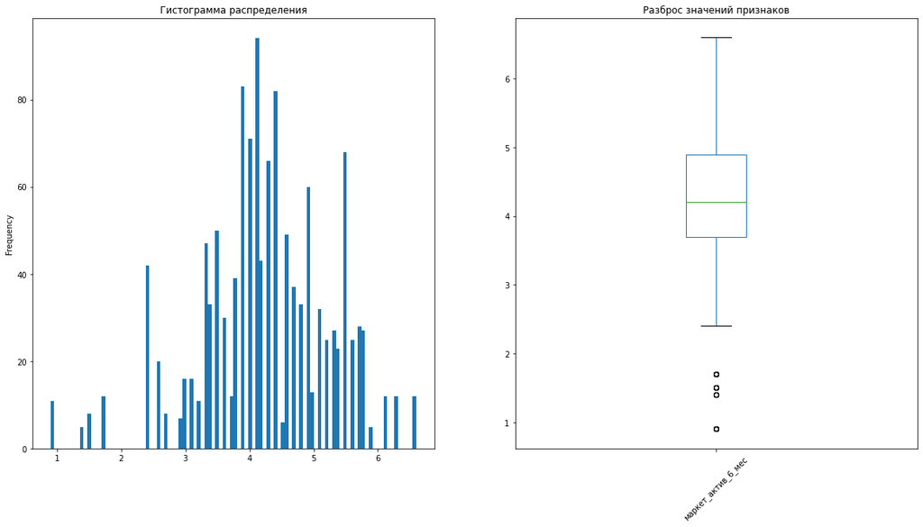

```
Наименование столбца:  маркет_актив_тек_мес
```

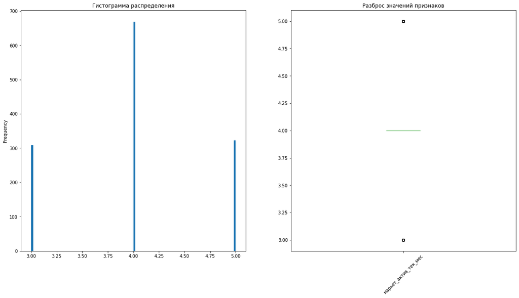

```
Наименование столбца:  длительность
```

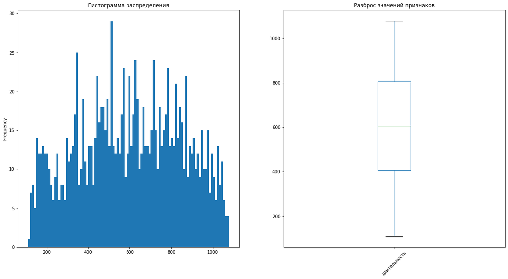

```
Наименование столбца:  акционные_покупки
```

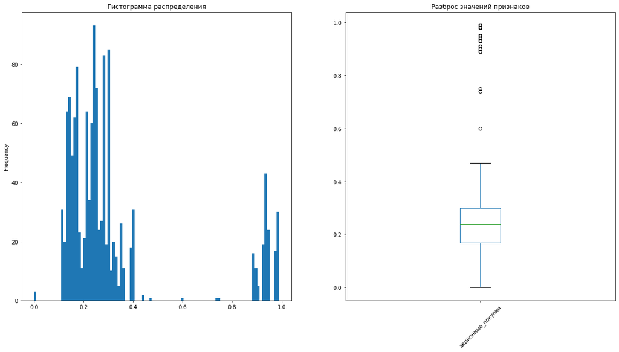

```
Наименование столбца:  средний_просмотр_категорий_за_визит
```

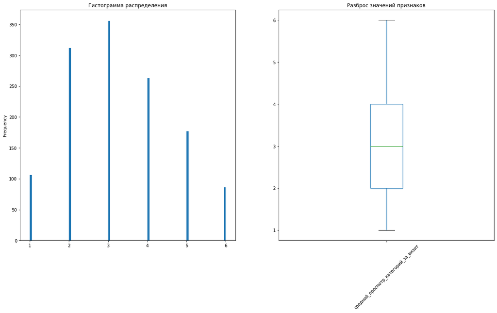

```
Наименование столбца:  неоплаченные_продукты_штук_квартал
```

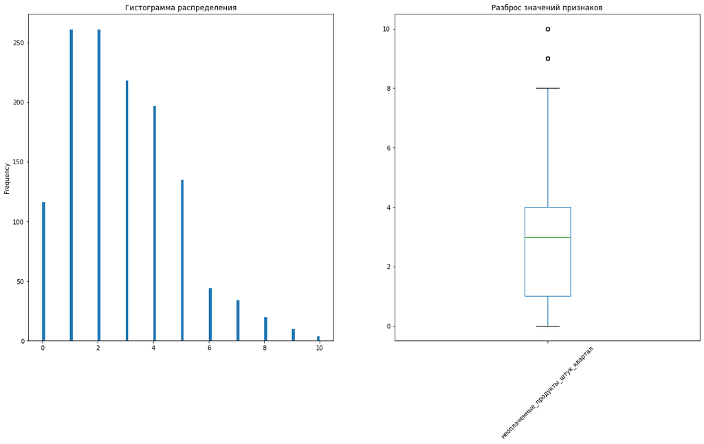

```
Наименование столбца:  ошибка_сервиса
```

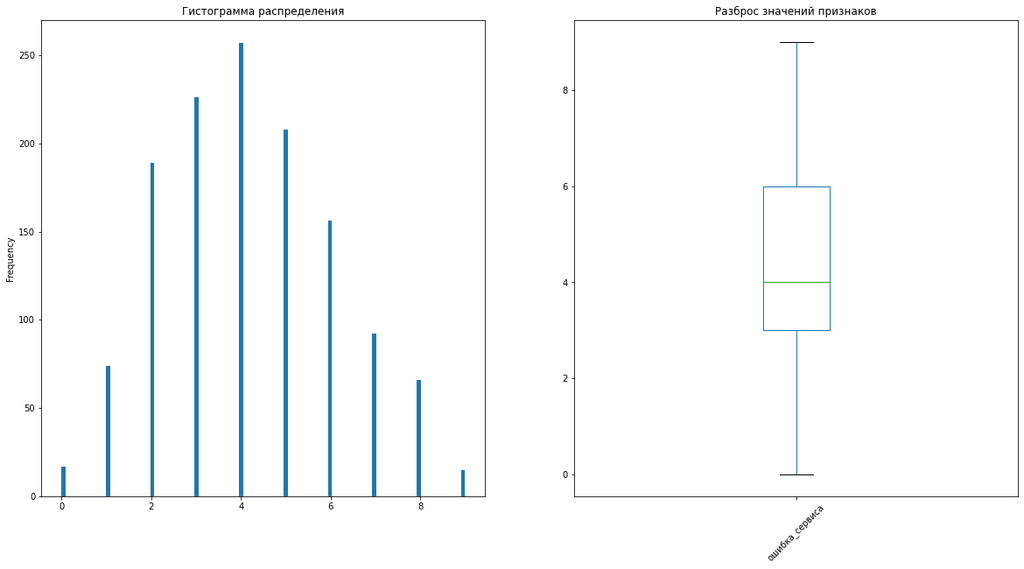

```
Наименование столбца:  страниц_за_визит
```

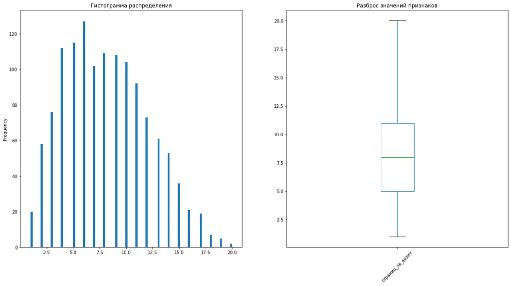

```
Таблица:  market_money
Наименование столбца:  выручка
```

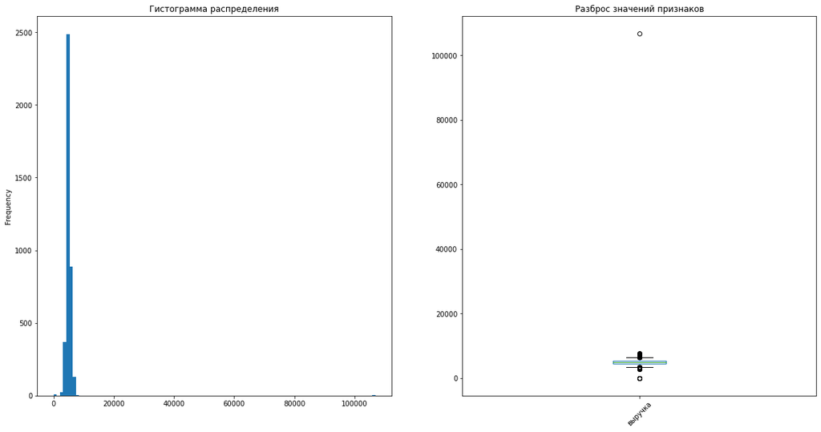

```
Таблица:  market_time
Наименование столбца:  минут
```

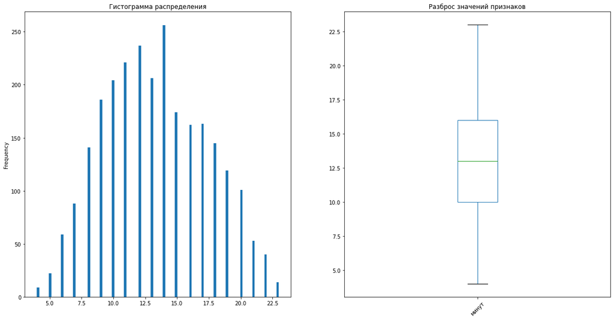

```
Таблица:  money
Наименование столбца:  прибыль
```

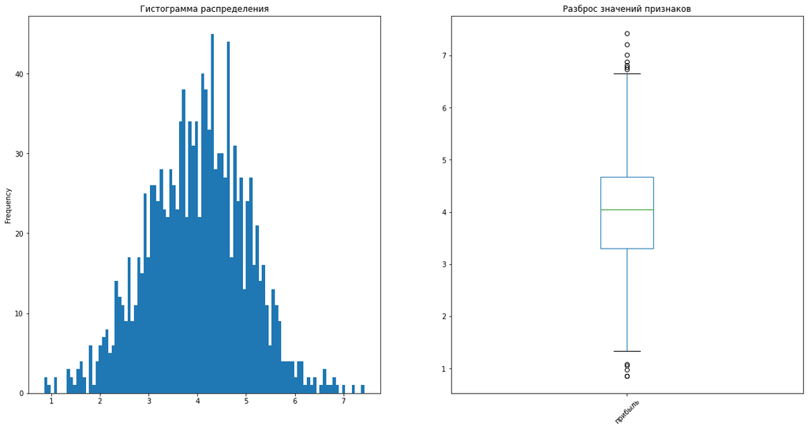

```python
for row in dictionary_with_frames:
    print(big_bold_text('Таблица: '),row)
    for row_1 in dictionary_with_frames[row].select_dtypes(include=np.number).drop('id',axis = 1):
        print(big_bold_text('Наименование столбца: '),row_1)
        fig, axes = plt.subplots(nrows=1, ncols=2, figsize=(20,10))
        dictionary_with_frames[row][row_1].plot(kind='hist', bins=100, ax=axes[0])
        axes[0].set_title('Гистограмма распределения')
        dictionary_with_frames[row][row_1].plot(kind='box', ax=axes[1], rot=45)
        axes[1].set_title('Разброс значений признаков')
        plt.show()
```

Удалим выбросы из выручки

```python
market_money.loc[market_money['выручка']==max(market_money['выручка'])]
```

|  | id | период | выручка |
| --- | --- | --- | --- |
| 98 | 215380 | текущий_месяц | 106862.2 |

```python
market_money.loc[market_money['id']==215380]
```

|  | id | период | выручка |
| --- | --- | --- | --- |
| 96 | 215380 | препредыдущий_месяц | 5051.0 |
| 97 | 215380 | предыдущий_месяц | 6077.0 |
| 98 | 215380 | текущий_месяц | 106862.2 |

Так как данных в нашей выборке достаточно, принимаю решение об удалении не только строки с выбросом, а полностью информацию о клиенте с id = 215380

```python
market_money = market_money.loc[market_money['id']!=215380].reset_index(drop = True)
```

**Построим графики категориальных данных**

```
Таблица:  market_file
Наименование столбца:  покупательская_активность
```

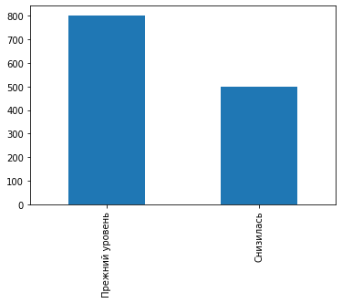

```
Наименование столбца:  тип_сервиса
```

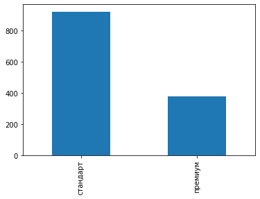

```
Наименование столбца:  разрешить_сообщать
```

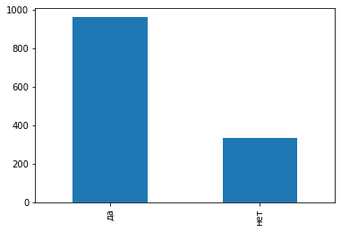

```
Наименование столбца:  популярная_категория
```

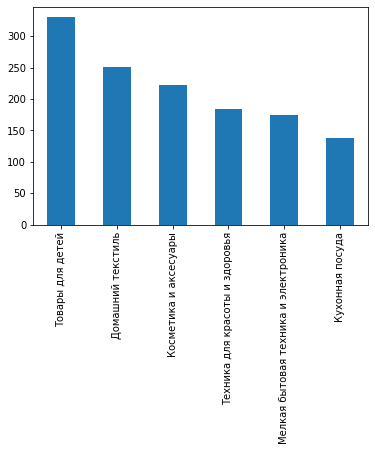

```
Таблица:  market_money
Наименование столбца:  период
```

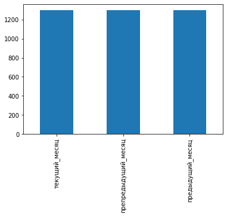

```
Таблица:  market_time
Наименование столбца:  период
```

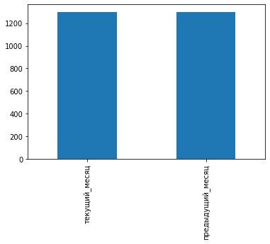

```
Таблица:  money
```

```python
for row in dictionary_with_frames:
    print(big_bold_text('Таблица: '),row)
    for row_1 in dictionary_with_frames[row].select_dtypes(exclude=np.number):
        print(big_bold_text('Наименование столбца: '),row_1)
        dictionary_with_frames[row][row_1].value_counts().plot(kind='bar')
        plt.show()
```

**Вывод:**

## Объединение таблиц

Транспанируем таблицы **market_money** и **market_time**

```python
market_money_piv = pd.pivot_table(market_money, index='id', columns='период', values='выручка')
market_money_piv = market_money_piv.set_axis(market_money_piv.columns.tolist(), axis=1).reset_index()
```

```python
market_time_piv = pd.pivot_table(market_time, index = 'id', columns = 'период', values = 'минут')
market_time_piv = market_time_piv.set_axis(market_time_piv.columns.tolist(), axis = 1).reset_index()
```

Сделаем объединение таблиц в одну

```python
merge_df = market_file.merge(market_money_piv, on = 'id', how = 'left')
```

```python
merge_df_full = merge_df.merge(market_time_piv, on = 'id', how = 'left')
```

```python
merge_df_full = merge_df_full[~np.isnan(merge_df_full['предыдущий_месяц_x'])].reset_index(drop=True)
```

```python
len(merge_df_full)
```

```
1299
```

**Вывод:**

1. Данные сгруппированы для удобства восприятия и объединения
2. Данные объединены в один df для дальнейшей работы

```python
merge_df_full['покупательская_активность'].unique()
```

```
array(['Снизилась', 'Прежний уровень'], dtype=object)
```

**Построим графики числовых признаков по целевому признаку. Изучим поведение различных групп клиентов**

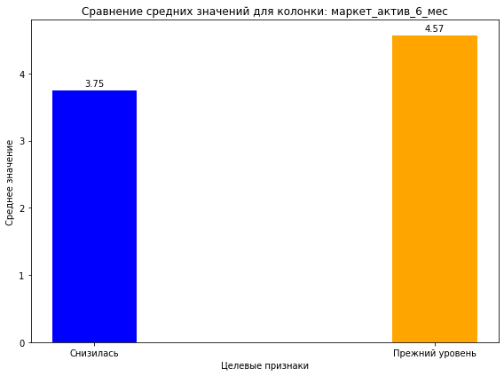

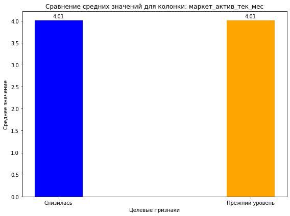

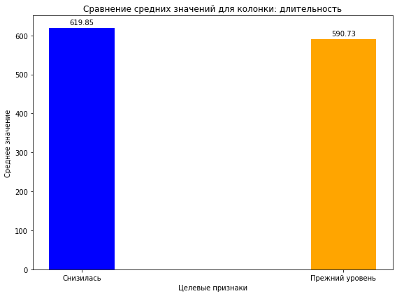

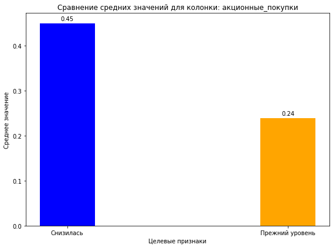

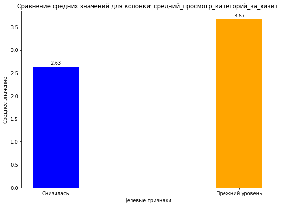

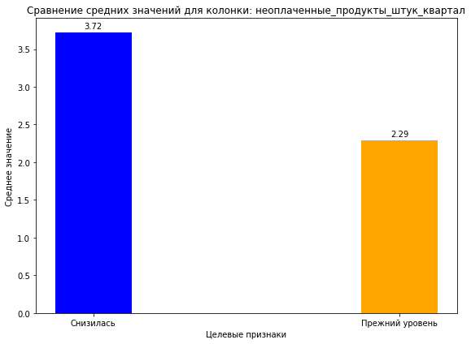

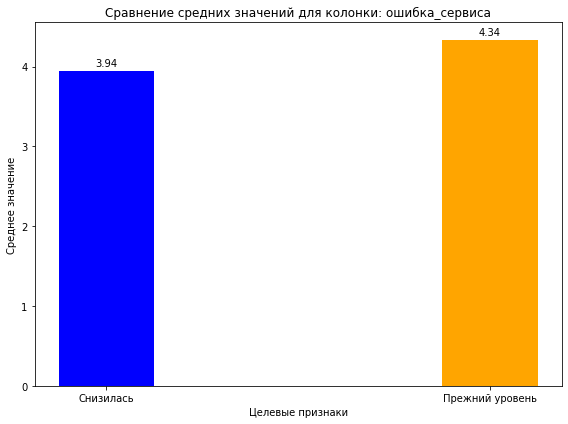

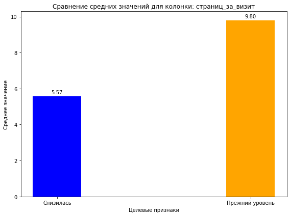

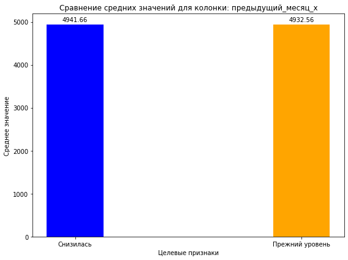

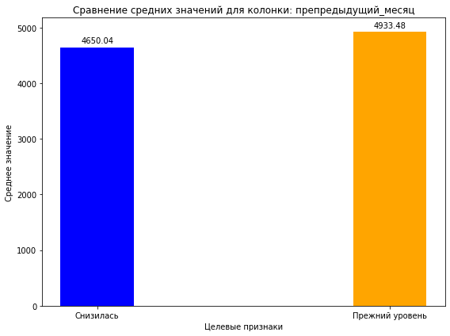

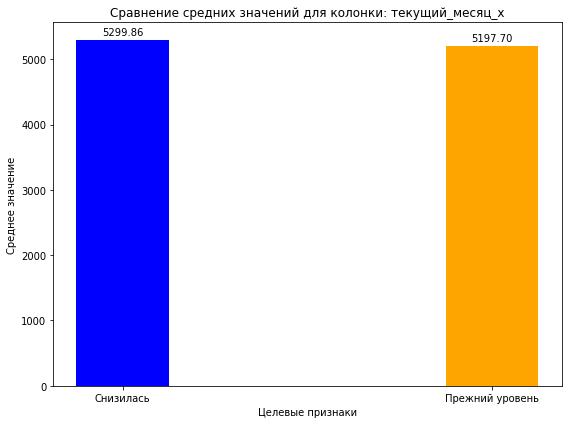

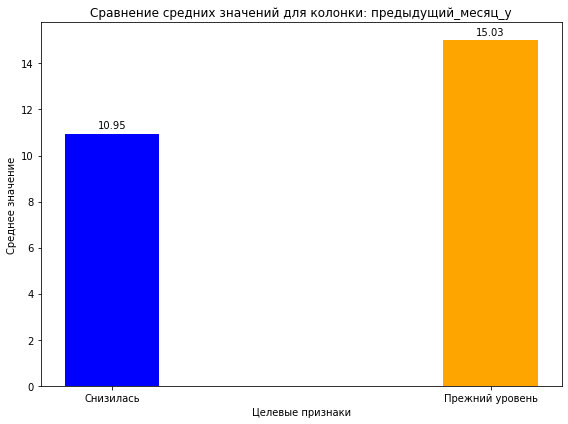

[1 more figures not shown]

```python
# Список колонок для анализа
col = merge_df_full.select_dtypes(include=[np.number]).drop('id', axis=1).columns

for row in col:
    # Вычисляем средние значения для каждого целевого признака по текущей колонке
    p_1 = merge_df_full[merge_df_full['покупательская_активность'] == 'Снизилась'][row].mean()
    p_2 = merge_df_full[merge_df_full['покупательская_активность'] == 'Прежний уровень'][row].mean()

    # Построение графика для текущей колонки
    x = np.array([0, 0.2])  # два столбца: один для 'Снизилась', другой для 'Прежний уровень'
    width = 0.05  # ширина столбцов

    # Создаем график
    fig, ax = plt.subplots(figsize=(8, 6))

    # Столбцы для p_1 и p_2
    bars = ax.bar(x, [p_1, p_2], width, color=['blue', 'orange'])

    # Настройки осей и легенды
    ax.set_xlabel('Целевые признаки')
    ax.set_ylabel('Среднее значение')
    ax.set_title(f'Сравнение средних значений для колонки: {row}')
    ax.set_xticks(x)
    ax.set_xticklabels(['Снизилась', 'Прежний уровень'])

    # Добавление значений над столбцами
    def add_labels(bars):
        for bar in bars:
            height = bar.get_height()
            ax.annotate(f'{height:.2f}',  # форматируем число с двумя знаками после запятой
                        xy=(bar.get_x() + bar.get_width() / 2, height),  # позиция текста
                        xytext=(0, 3),  # небольшое смещение вверх
                        textcoords="offset points",
                        ha='center', va='bottom')

    add_labels(bars)

    plt.tight_layout()
    plt.show()
```

**Построим графики категориальных признаков по целевому признаку. Изучим поведение различных групп клиентов**

```python
# Список колонок для анализа
col = merge_df_full.select_dtypes(exclude=[np.number]).drop('покупательская_активность', axis=1).columns
```